# Network Visualization

Mark Hoffman

May 16, 2016

As social scientists, we want to tell convincing stories about the structure and dynamics of the networks we study. Visualization and statistics are the primary tools at our disposable for conveying these stories.

In this tutorial we will learn how to change the aesthetics of our network visualizations. When visualizing networks, there are a number of different elements we can adjust. First, we can change the color, size, shapes and labels of nodes. Second, we can change the color, width, curviture and appearance of edges. Finally, we can manipulate the layout of the network.

We can affect any of these aesthetics arbitrarily. You might prefer the way networks look when the edges are curved as opposed to straight for example. However, we often make decisions informed by theories we have about our empirical setting. If we think that race is important to the structure of the network, we might color nodes according to race. If we think both race and gender are important, we could color nodes by race and change the shape of nodes by gender. We could also size nodes according to wealth.

We are generally limited to visualizing three attributes at once (color, shape and size), though I find that anything more than two (color and size) is difficult to interpret.

# Adding attributes to a network

It follows that most network projects necessitate two separate datasets. In addition to a dataset of relations, which we covered in the previous tutorial, we need a second dataset that details actors’ attributes. Here is an example:

```r
actorid <- c(1:5)
actorname <- c("Mark", "Peter", "Jill", "Bob", "Aaron")
age <- c(23,40,20,77,13)
gender <- c("M", "M", "F", "M", "M")
race <- c("W", "B", "W", "A", "H")
country <- c("USA", "France", "South Africa", "Indonesia", "Bolivia")

attributes <- data.frame(ID = actorid, Name = actorname, Age = age, Gender = gender, Race = race, Country = country, stringsAsFactors = F)

print(attributes)
```

```
##   ID  Name Age Gender Race      Country
## 1  1  Mark  23      M    W          USA
## 2  2 Peter  40      M    B       France
## 3  3  Jill  20      F    W South Africa
## 4  4   Bob  77      M    A    Indonesia
## 5  5 Aaron  13      M    H      Bolivia
```

We can load node attributes into R using read.csv as before.

```r
countrysideAtts <- read.csv("Data/countrysideAtts.csv", stringsAsFactors = F)
head(countrysideAtts)
```

```
##   name sex race grade
## 1    1   1    1    10
## 2    2   2    5    10
## 3    3   2    2    10
## 4    4   1    1    10
## 5    5   2    3    11
## 6    6   2    2    11
```

This gives us a data.frame, in which each column corresponds to an attribute of the nodes in our network and each row corresponds to a particular node.

To use these attributes in igraph, we have to assign them to the nodes. Attributes in igraph are assigned to nodes and edges separately. As mentioned in the previous tutorial, vertices are accessed using the V() function while edges are accessed with the E() function. Attributes are then accessed with the $ operator followed by the attribute name.

For example, as we showed earlier, V(countrysideNetwork)$name will tell us the names of all of the nodes in the network. To change the attribute we want to call, we just change what follows the $.

```r
V(countrysideNetwork)$name[1:20]
```

```
##  [1] "1"  "2"  "3"  "4"  "5"  "6"  "7"  "8"  "9"  "10" "11" "12" "13" "14"
## [15] "15" "16" "17" "18" "19" "20"
```

```r
V(countrysideNetwork)$sex[1:20]
```

[output not shown]

We therefore need to attach the attributes from our attribute file to our network. The method for doing can be a bit complicated.

If we have an edge list, we can use the _from_data_frame() function instead of graph.edgelist(), and include the attributes file as the vertices argument. In this case, the edge list needs to be a data.frame.

```r
countrysideEL <- read.csv("Data/countrysideEL.csv", stringsAsFactors = F)

countrysideAtts <- read.csv("Data/countrysideAtts.csv", stringsAsFactors = F)

countrysideNetwork <- graph_from_data_frame(countrysideEL, directed = T, vertices = countrysideAtts)
```

Now, if we look at our network, we will see that there are many more next to attr.

```r
countrysideNetwork
```

```
## IGRAPH DN-- 1147 6189 --
## + attr: name (v/c), sex (v/n), race (v/n), grade (v/n)
## + edges (vertex names):
##  [1] 1 ->262 1 ->542 1 ->958 2 ->401 2 ->559 3 ->64  3 ->67  3 ->293
##  [9] 3 ->432 3 ->485 3 ->598 3 ->631 3 ->648 5 ->229 5 ->325 5 ->504
## [17] 6 ->127 6 ->395 7 ->6   7 ->75  9 ->12  9 ->65  9 ->139 9 ->175
## [25] 9 ->296 9 ->406 9 ->516 10->522 11->195 11->227 11->331 11->355
## [33] 11->367 11->453 11->466 11->487 12->9   12->171 12->406 12->458
## [41] 12->516 13->25  13->124 13->239 13->335 13->353 13->395 13->476
## [49] 13->569 13->643 14->13  14->16  14->336 14->793 15->303 15->474
## [57] 15->475 15->571 15->649 16->17  16->75  16->422 16->467 16->495
## + ... omitted several edges
```

We can look at each one with the V()$ function

```r
V(countrysideNetwork)$race[1:20]
```

```
##  [1] 1 5 2 1 3 2 2 2 2 1 1 2 2 2 1 2 2 1 3 1
```

Alternatively, you can use a function I included in the “Useful R Functions” folder called “assign_atts.R”. It takes two arguments: an igraph object and an attributes data.frame. The only requirements for the data.frame is that it has a column called “name” which allows the rows in the data.frame to be matched to the nodes in the network and at least one other column to be assigned as the attribute.

```r
source("Useful R Functions/assign_atts.r")
countrysideNetwork <- assign_atts(countrysideNetwork, countrysideAtts)
```

The ifelse function is useful for this purpose. The basic structure is: if something is true, then do this, otherwise do something different.

```r
V(countrysideNetwork)$nonwhite <- ifelse(V(countrysideNetwork)$race == 2 | V(countrysideNetwork)$race == 3, 1, 0)
```

Alternatively we could perform some mathematical observations on the variable values.

```r
V(countrysideNetwork)$grade2 <- V(countrysideNetwork)$grade2^2
```

# Plotting Basics

Visualizing the network is as simple as typing plot(countrysideNetwork). There are many arguments for plot, which we will go over. As I mentioned earlier, the default plot is really horrible (but it used to be worse…)

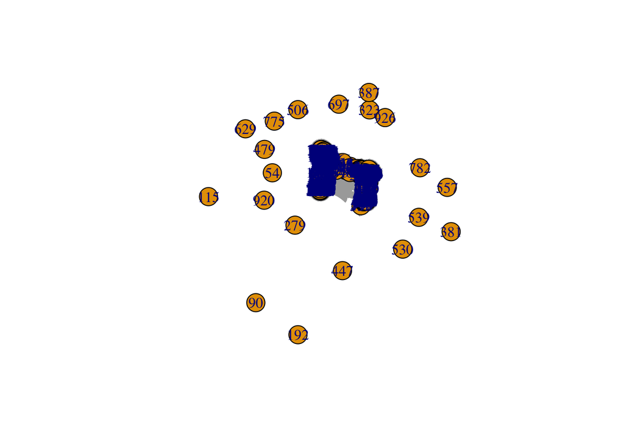

```r
plot(countrysideNetwork)
```

What is horrible about the default plot? First of all, the nodes are too large and clumped together, so let’s adjust the size. The argument vertex.size allows us to adjust vertex size.

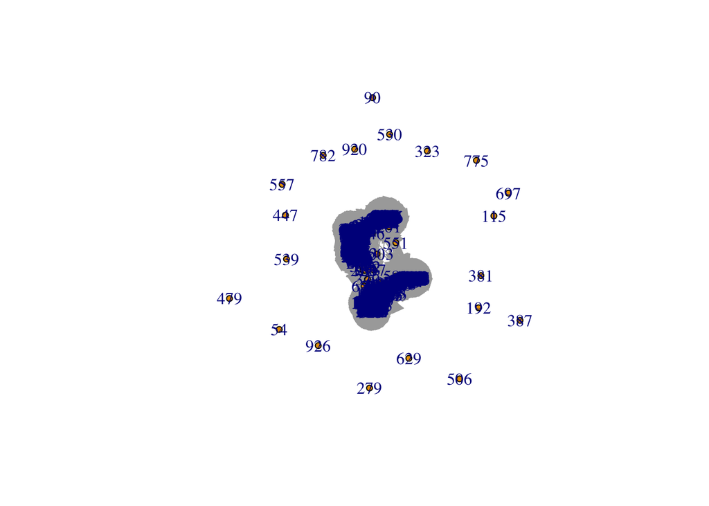

```r
plot(countrysideNetwork, vertex.size = 4)
```

Node color is also an ugly light orange, but we can use vertex.color to change it to something nicer. We can also remove the ugly black frames by setting the vertex.frame.color argument to NA.

> **Useful Link** You can find a list of all the named colors in R at http://www.stat.columbia.edu/~tzheng/files/Rcolor.pdf

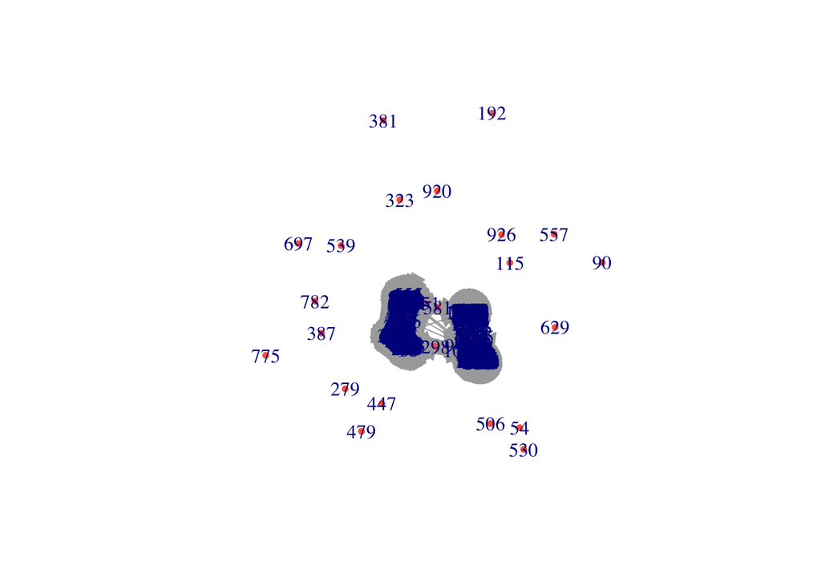

```r
plot(countrysideNetwork, vertex.size = 4, vertex.color = "tomato", vertex.frame.color = NA)
```

The labels are too large and blue. We can adjust label size with vertex.label.cex. We can adjust the color with vertex.label.color

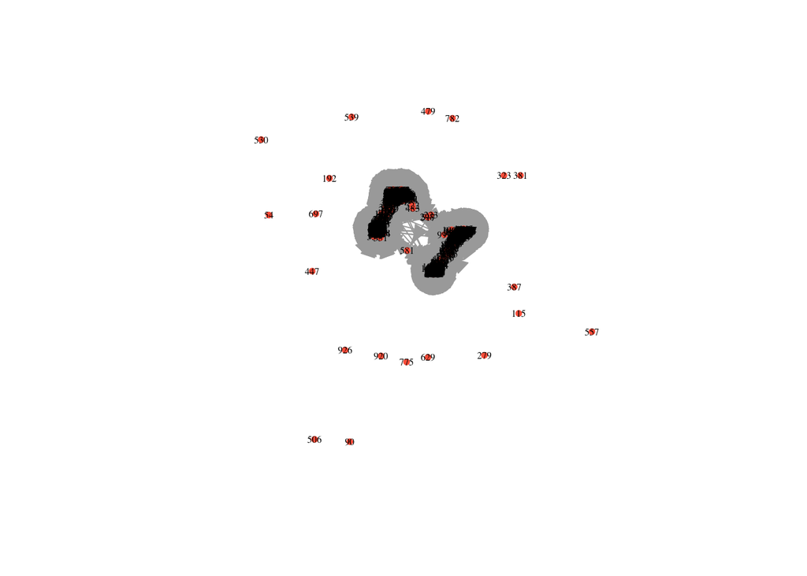

```r
plot(countrysideNetwork, vertex.size = 4, vertex.color = "tomato", vertex.frame.color = NA, vertex.label.cex = .5, vertex.label.color = "black")
```

Alternatively, if we want to get rid of the labels, we can just set vertex.label to NA.

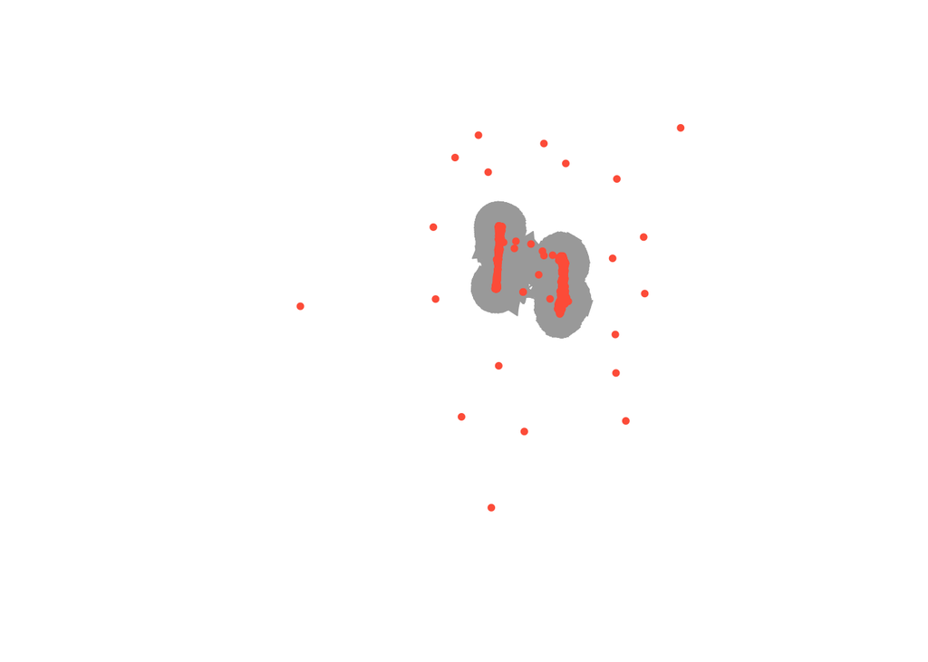

```r
plot(countrysideNetwork, vertex.size = 4, vertex.color = "tomato", vertex.frame.color = NA, vertex.label = NA)
```

Finally we can make the edges smaller and curved to give them a nicer aesthetic

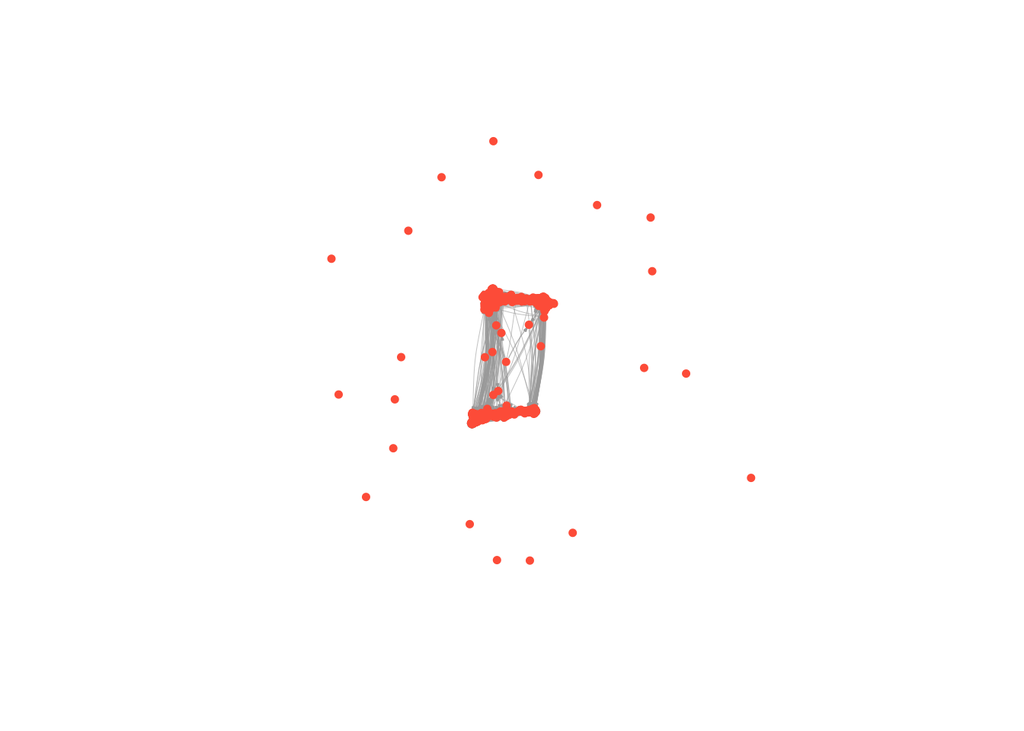

```r
plot(countrysideNetwork, vertex.size = 4, vertex.color = "tomato", vertex.frame.color = NA, vertex.label.cex = .7,  vertex.label = NA, edge.curved = .1, edge.arrow.size = .1, edge.width = .3)
```

The network still looks a bit distant. This is because the isolates are messing up igraph’s plotting function, so let’s try dropping them. The easiest way is to use the giant.component function included in the “Useful R Functions” folder.

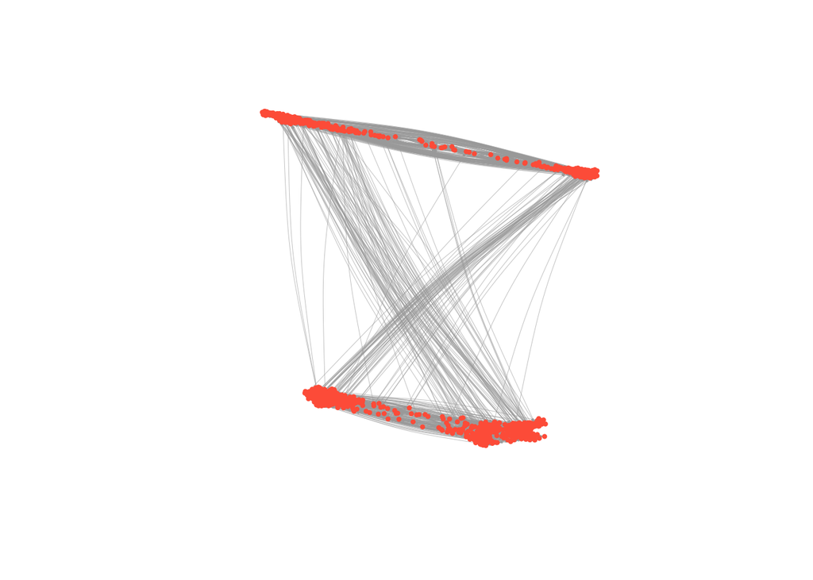

```r
source("Useful R Functions/giant_component.R")
countrysideNetwork <- giant_component(countrysideNetwork)

plot(countrysideNetwork, vertex.size = 3, vertex.color = "tomato", vertex.frame.color = NA, vertex.label.cex = .7,  vertex.label = NA, edge.curved = .1, edge.arrow.size = .1, edge.width = .3)
```

# Layouts

There are a wide range of layouts that have been developed for social network analysis. They all try to minimize the number of edges that cross, but use different algorithms for achieving this goal. Generally, I use either the Kamada Kawai algorithm or the Fruchterman Reingold algorithm.

igraph has set of layout functions which, when passed a network object, return an array of coordinates that can then used when plotting that network. These coordinates should be saved to a separate R object, which is then called within the plot function. They all have the format: layout DOT algorithm name. For example, layout.kamada.kawai() or layout.fruchterman.reingold()

**Kamada Kawai**

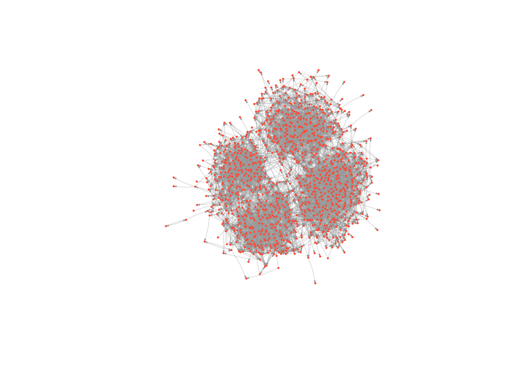

```r
kamadaLayout <- layout.kamada.kawai(countrysideNetwork)

plot(countrysideNetwork, layout = kamadaLayout, vertex.size = 2, vertex.color = "tomato", vertex.frame.color = NA, vertex.label.cex = .7,  vertex.label = NA, edge.curved = .1, edge.arrow.size = .1, edge.width = .3)
```

**Frucherman-Reingold**

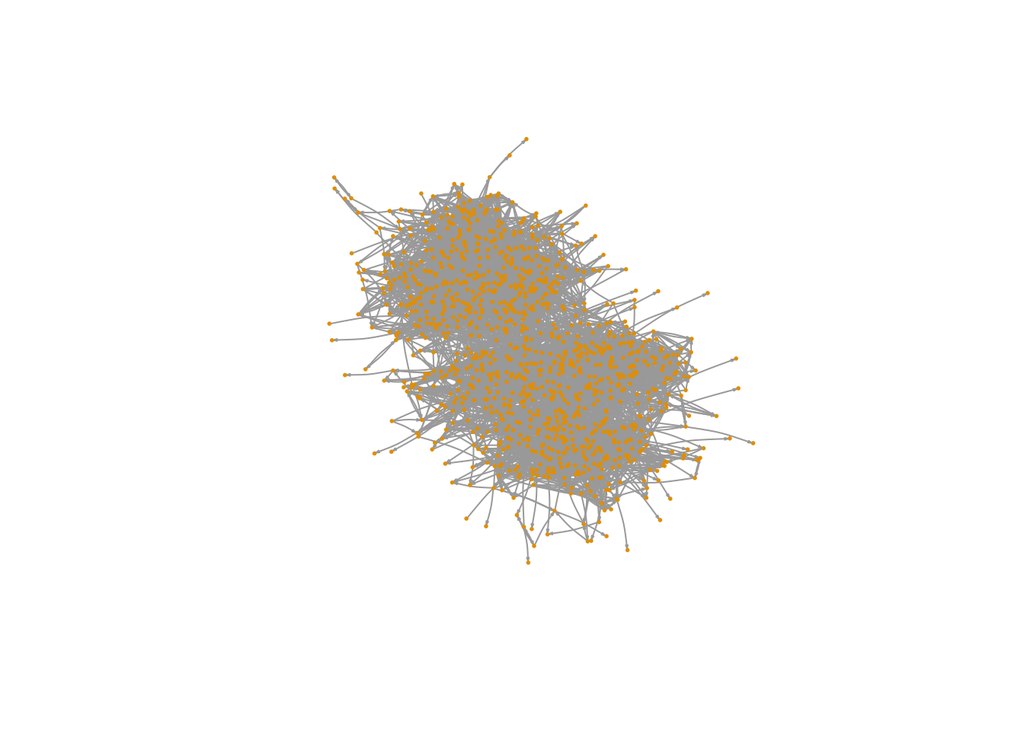

```r
fruchtermanLayout <- layout.fruchterman.reingold(countrysideNetwork)

plot(countrysideNetwork, layout = fruchtermanLayout, vertex.size = 2, vertex.color = V(countrysideNetwork)$color, vertex.frame.color = NA, vertex.label.cex = .7, vertex.label = NA, edge.curved = .1, edge.arrow.size = .1)
```

You can see ?layout_ for more options and details

# Coloring by Attributes

In the last tutorial, we imported attributal data into our network object, which will allow us to manipulate our network according to nodal attributes. Let’s start by manipulating color according to sex.

To do this we use the ifelse function. As a reminder, the ifelse() function takes three arguments. The first is a test (something that evaluates to TRUE or FALSE), the second is what to return if the test is TRUE and third is what to return if the test evaluates to FALSE.

We therefore set up an ifelse function, which tests whether a node’s sex is male, assigning it the color “blue” if TRUE and “green” if FALSE.

```r
V(countrysideNetwork)$color <- ifelse(V(countrysideNetwork)$sex == 1, "dodgerblue3","seagreen")
```

Finally we can replot the network but this time, a node’s color will be green or blue depending on their sex.

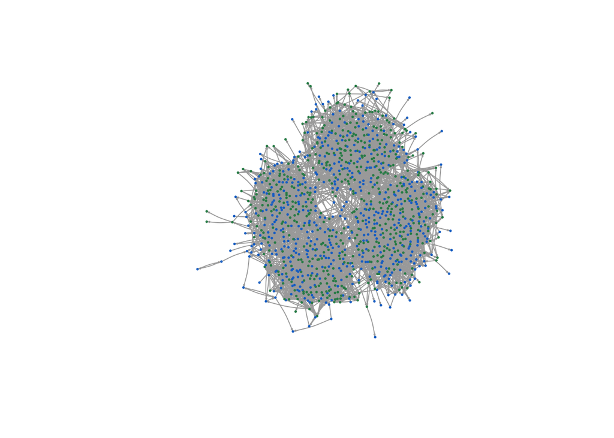

```r
plot(countrysideNetwork, layout = kamadaLayout, vertex.size = 2, vertex.color = V(countrysideNetwork)$color, vertex.frame.color = NA, vertex.label.cex = .7, vertex.label = NA, edge.curved = .1, edge.arrow.size = .1)
```

Now let’s try race. First, I reset color. There are five races, so we need a few more ifelse statements to recode all of them.

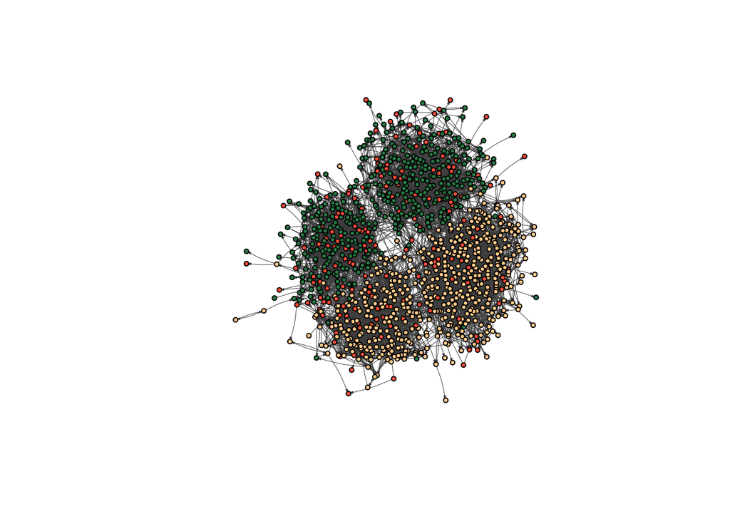

```r
V(countrysideNetwork)$color <- NA
V(countrysideNetwork)$color <- ifelse(V(countrysideNetwork)$race == 1, "burlywood1","tomato")

V(countrysideNetwork)$color <- ifelse(V(countrysideNetwork)$race == 2, "seagreen", V(countrysideNetwork)$color)

plot(countrysideNetwork, layout = kamadaLayout, vertex.size = 3, vertex.color = V(countrysideNetwork)$color, vertex.label.cex = .7, vertex.label = NA, edge.curved = .1, vertex.frame.color = "black", edge.arrow.size = .1, edge.width = .5, edge.color = "grey30")
```

There it is! Just like the one from the slides.